# R Notebook

```r
library(tidyverse)
library(modelr)
library(broom)
library(ggfortify)
```

```r
project <- read_csv("data/project_management.csv")
head(project)
```

| X1 | estimated_length | actual_length |
| --- | --- | --- |
| 1 | 12 | 17 |
| 2 | 16 | 22 |
| 3 | 16 | 23 |
| 4 | 18 | 25 |
| 5 | 22 | 39 |
| 6 | 19 | 24 |

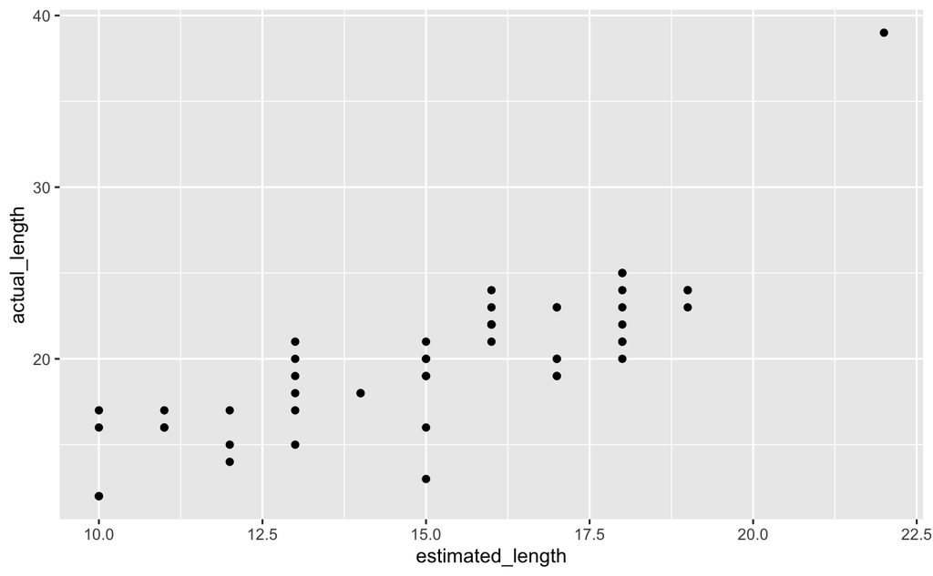

```r
project %>%
  ggplot(aes(x = estimated_length, y = actual_length)) +
  geom_point()
```

```r
project %>%
  summarise(cor = cor(estimated_length, actual_length))
```

| cor |
| --- |
| 0.8046597 |

It has very strong positive correlation coefficient between two variables.

```r
summary(model)
```

```
Call:
lm(formula = actual_length ~ estimated_length, data = project)

Residuals:
    Min      1Q  Median      3Q     Max
-6.7687 -1.6513  0.1195  1.1252 10.6669

Coefficients:
                 Estimate Std. Error t value Pr(>|t|)
(Intercept)        1.4164     2.0069   0.706    0.484
estimated_length   1.2235     0.1303   9.389 1.91e-12 ***
---
Signif. codes:  0 ‘***’ 0.001 ‘**’ 0.01 ‘*’ 0.05 ‘.’ 0.1 ‘ ’ 1

Residual standard error: 2.606 on 48 degrees of freedom
Multiple R-squared:  0.6475,    Adjusted R-squared:  0.6401
F-statistic: 88.16 on 1 and 48 DF,  p-value: 1.911e-12
```

The regression equation is:

actual_lengthˆ=1.4164+1.2235×estimated_length so a 1 day increase in estimated_length is associated with a 1.2235 day increase in actual_length, i.e. the company is underestimating job lengths.

The r2 value tells us that approximately 65% of the variation in actual_length can be predicted from the variation in estimated_length.

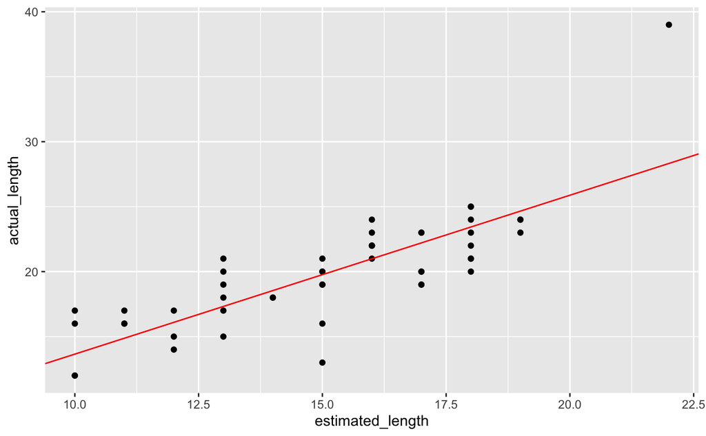

```r
project %>%
  ggplot(aes(x = estimated_length, y = actual_length)) +
  geom_point() +
  geom_abline(
    intercept = model$coefficients[1],
    slope = model$coefficients[2],
    col = "red"
  )
```

```r
glance(model)
```

| r.squared | adj.r.squared | sigma | statistic | p.value | df | logLik | AIC | BIC | deviance | df.residual | nobs |
| --- | --- | --- | --- | --- | --- | --- | --- | --- | --- | --- | --- |
| 0.6474772 | 0.640133 | 2.606163 | 88.16142 | 1.911284e-12 | 1 | -117.8203 | 241.6407 | 247.3767 | 326.0201 | 48 | 50 |

The line does not fit all the data. Probably due to outliers.

```r
tidy(model)
```

| term | estimate | std.error | statistic | p.value |
| --- | --- | --- | --- | --- |
| (Intercept) | 1.416379 | 2.0069491 | 0.7057375 | 4.837627e-01 |
| estimated_length | 1.223489 | 0.1303049 | 9.3894314 | 1.911284e-12 |

[output not shown]

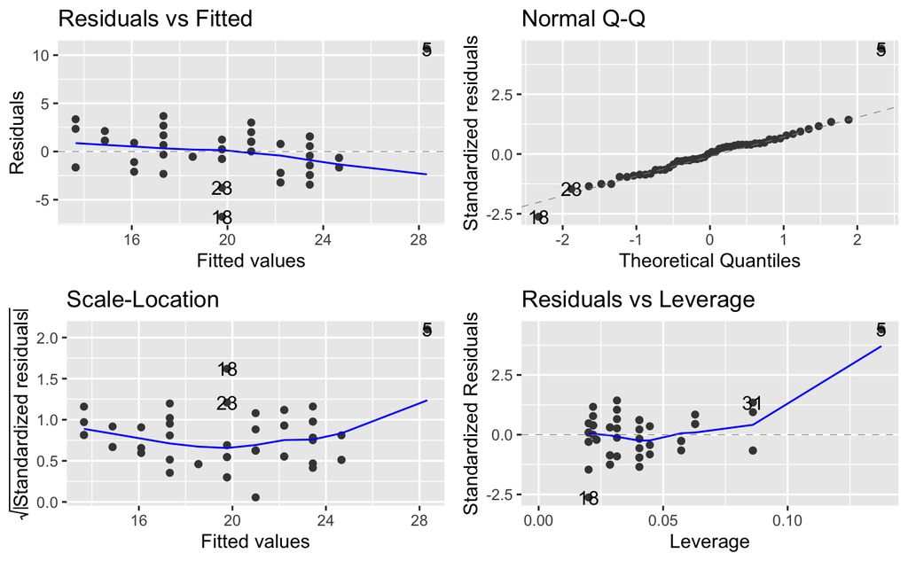

```r
autoplot(model)
```

Aside from outliers (certainly point 5 , and perhaps point 18 ), the diagnostic plots looks reasonable. The ‘Residuals vs Fitted’ plot reveals independent residuals, the ‘Normal Q-Q’ plot looks fine, and there is no systematic upward or downward trend in the the ‘Scale-Location’ plot.

The relationship is statistically significant, as the p -value of the slope is much less than a typical α of 0.05.

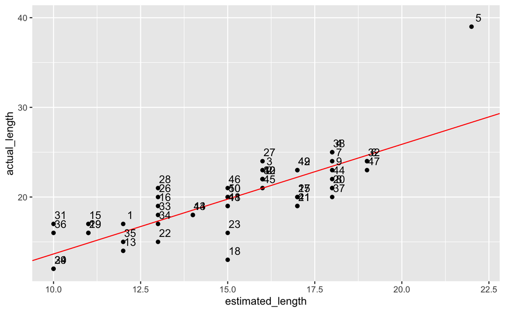

```r
project %>%
  ggplot(aes(x = estimated_length, y = actual_length)) +
  geom_point() +
  geom_abline(
    intercept = model$coefficients[1],
    slope = model$coefficients[2],
    col = "red"
  ) +
  geom_text(aes(label = 1:nrow(project)), nudge_x = 0.2, nudge_y = 1)
```

Outliers: 5, 18 Influential: 5 Non-influential: 18

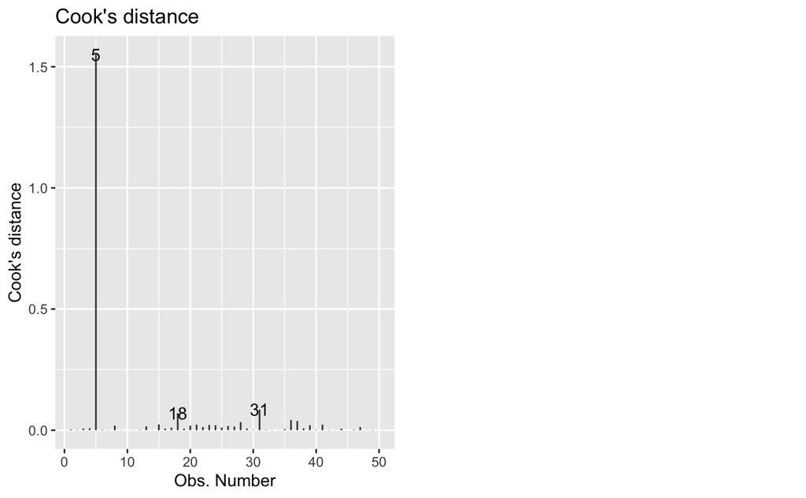

```r
autoplot(model, which = 4)
```

[figure not shown]

[figure not shown]

[figure not shown]

[figure not shown]

The Cook’s distance plot confirms that point 5 is an ‘influential’ outlier, as it lies above 1 . In fact, this threshold is rather arbitrary, a better method is to look to see if any observation has a Cook’s distance substantially greater than the others. If so, examine that observation. So we would definitely want to look again at the data gathered and the estimation process for the job on row 5 to see if any errors were made.

Point 18 is an outlier, but is ‘non-influential’, as it has a Cook’s distance similar to the other points.

```r
non_inf <- project %>%
  slice(-c(18, 15, 13))

model_non_inf <- lm(formula = actual_length ~ estimated_length, data = non_inf)
model_non_inf
```

```
Call:
lm(formula = actual_length ~ estimated_length, data = non_inf)

Coefficients:
     (Intercept)  estimated_length
           1.552             1.224
```

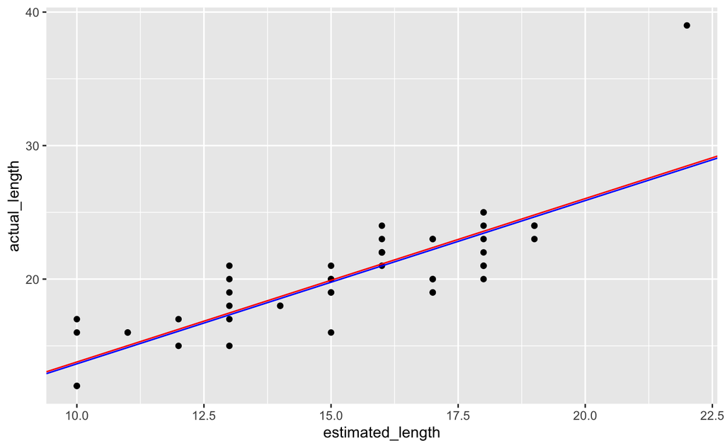

```r
non_inf %>%
  ggplot(aes(x = estimated_length, y = actual_length)) +
  geom_point() +
  geom_abline(
    intercept = model_non_inf$coefficients[1],
    slope = model_non_inf$coefficients[2],
    col = "red"
  ) +
  geom_abline(
    intercept = model$coefficients[1],
    slope = model$coefficients[2],
    col = "blue"
  )
```

```r
inf <- project %>%
  slice(-c(5, 22,39))

model_inf <- lm(formula = actual_length ~ estimated_length, data = inf)
model_inf
```

```
Call:
lm(formula = actual_length ~ estimated_length, data = inf)

Coefficients:
     (Intercept)  estimated_length
          5.3473            0.9546
```

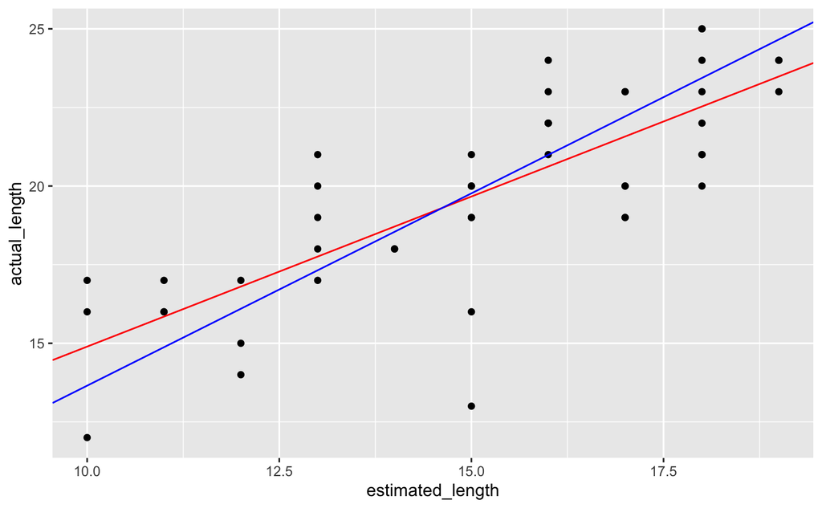

```r
inf %>%
  ggplot(aes(x = estimated_length, y = actual_length)) +
  geom_point() +
  geom_abline(
    intercept = model_inf$coefficients[1],
    slope = model_inf$coefficients[2],
    col = "red"
  ) +
  geom_abline(
    intercept = model$coefficients[1],
    slope = model$coefficients[2],
    col = "blue"
  )
```

```r
NA
```